# transcriptomicsTemplates

December 9, 2019 - Bioconductor conference, Brussels.

## Overview

- Goal: **customized and semi-automated analysis** of microarray and bulk RNAseq data
- Authors: Laure Cougnaud, Kirsten Van Hoorde, Michela Pasetto, Katarzyna Górczak, Yingjie Zhang
- Tool: R package *transcriptomicsTemplates* and associated templates in *RMarkdown* format

## How it works

The user copies the original template and modifies towards a personal *RMarkdown* master document containing **analysis-specific input parameters**.

**Running the *RMarkdown* master document**:

- **calls other child templates contained in the package** (do not need manual modifications)
- creates:
  - an **html** report file associated to the *Rmd* template
  - *objects*/*graphs* folders with results/visualizations

## Available analyses

- unsupervised analysis (required)
- differential expression analysis (optional)
- overlap analysis (optional)
- pairwise comparison analysis (optional)

## Example dataset

- `ALL` dataset
- microarrays from patients with acute lymphoblastic leukemia
- covariates of interest:
  - gender: male/female
  - different disease type: B-cell/T-cell
  - different disease stage: 1 to 4
  - remission achieved or refractory
- data from: *Gene expression profile of adult T-cell acute lymphocytic leukemia identifies distinct subsets of patients with different response to therapy and survival, Chiaretti, et al. ,Blood type, 2004, 103*

## Unsupervised analysis

For a first glance at the data: **spectral map** of the entire dataset or a subset of samples of interest:

- with covariates-related aesthetics
- with different levels of annotation: sample, gene, gene set
- visualize genes/show table of pathways with highest score

## Spectral maps with gene and pathway annotation

[figure not shown]

## Differential expression analysis

- For **microarray**: `limma`
- For **RNAseq**: with `edgeR` and `DESeq2`
- several analyses of interest
- need to specify input model (*design matrix*, `lmFit` and `eBayes`)
- for each analysis, results are reported with:
  - volcano plots
  - top affected genes
  - top affected pathways

## Top affected genes

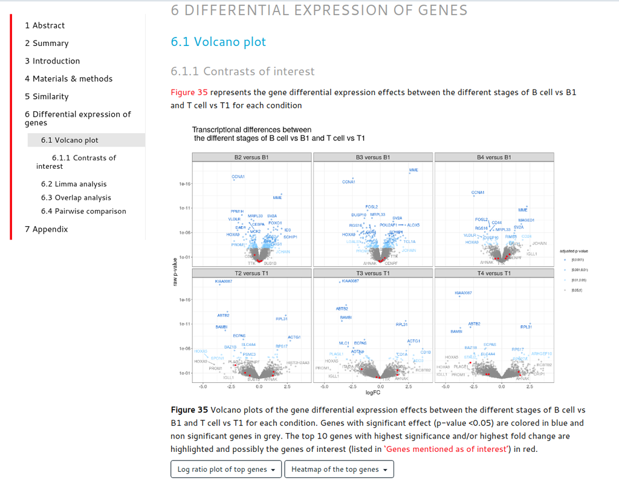

## Top affected pathways

- with the `MLP` package
- *Gene Ontology* (GO) databases (with the possibility to add additional pathway databases if specified by the user)
- results reporting:
  - tables of top pathways
  - visualizations: barplot of pathway significance and GO graph

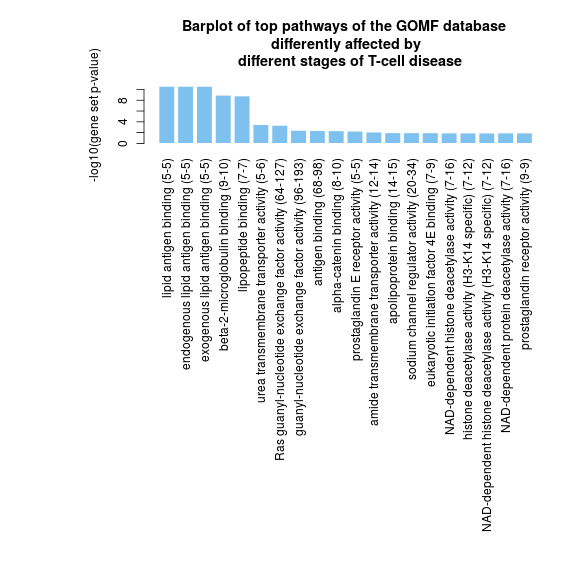

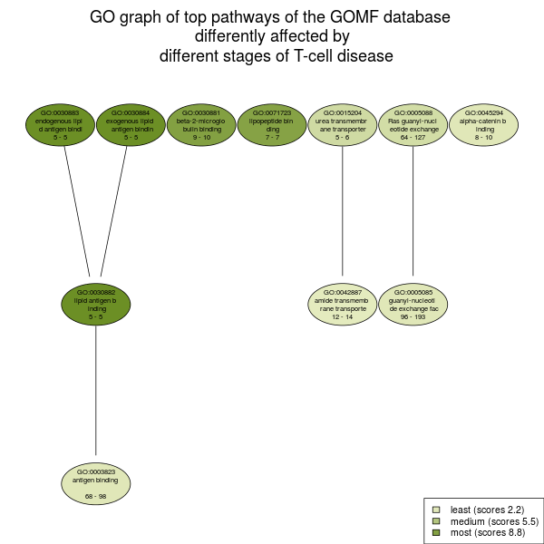

## Conclusion

The transcriptomicsTemplates package is a **transcriptional analysis workflow**:

- facilitates the analysis of transcriptional data on a daily basis
- standardize reports
- time-saving and less error-prone